# Assignment 6 RNAseqPart 1

**Name:** Eliza Tsang **Student ID:** 999606858

```r
library(rtracklayer)
gff <- import.gff("Brapa_reference/Brapa_gene_v1.5.gff")
summary(gff)
```

```
## [1] "GRanges object with 288624 ranges and 7 metadata columns"
```

```r
#create a column "gene_id" that contains the gene name for every entry
gff$gene_id <- ifelse(is.na(gff$ID),gff$Parent,gff$ID)

export(gff,"Brapa_reference/Brapa_gene_v1.5.gtf",format="gtf")
```

```r
library(Rsubread)
readCounts <- featureCounts(
  files=c("../Assignment_5_Tsang.Eliza/tophat_out-IMB211_All_A01_INTERNODE.fq/accepted_hits_A01.bam",
    "../Assignment_5_Tsang.Eliza/tophat_out-R500_All_A01_INTERNODE.fq/accepted_hits_A01.bam"),
  annot.ext="Brapa_reference/Brapa_gene_v1.5.gtf",
  isGTFAnnotationFile=TRUE,
  GTF.featureType="CDS", # This depends on GTF file.  Often it would be "exon"
  GTF.attrType="gene_id"
  )
```

```
##
##         ==========     _____ _    _ ____  _____  ______          _____
##         =====         / ____| |  | |  _ \|  __ \|  ____|   /\   |  __ \
##           =====      | (___ | |  | | |_) | |__) | |__     /  \  | |  | |
##             ====      \___ \| |  | |  _ <|  _  /|  __|   / /\ \ | |  | |
##               ====    ____) | |__| | |_) | | \ \| |____ / ____ \| |__| |
##         ==========   |_____/ \____/|____/|_|  \_\______/_/    \_\_____/
##        Rsubread 1.24.0
##
## //========================== featureCounts setting ===========================\\
## ||                                                                            ||
## ||             Input files : 2 BAM files                                      ||
## ||                           S ../Assignment_5_Tsang.Eliza/tophat_out-IMB ... ||
## ||                           S ../Assignment_5_Tsang.Eliza/tophat_out-R50 ... ||
## ||                                                                            ||
## ||             Output file : ./.Rsubread_featureCounts_pid9969                ||
## ||                 Summary : ./.Rsubread_featureCounts_pid9969.summary        ||
## ||              Annotation : Brapa_reference/Brapa_gene_v1.5.gtf (GTF)        ||
## ||      Dir for temp files : .                                                ||
## ||                                                                            ||
## ||                 Threads : 1                                                ||
## ||                   Level : meta-feature level                               ||
## ||              Paired-end : no                                               ||
## ||         Strand specific : no                                               ||
## ||      Multimapping reads : not counted                                      ||
## || Multi-overlapping reads : not counted                                      ||
## ||       Overlapping bases : 0.0%                                             ||
## ||                                                                            ||
## \\===================== http://subread.sourceforge.net/ ======================//
##
## //================================= Running ==================================\\
## ||                                                                            ||
## || Load annotation file Brapa_reference/Brapa_gene_v1.5.gtf ...               ||
## ||    Features : 206584                                                       ||
## ||    Meta-features : 41020                                                   ||
## ||    Chromosomes/contigs : 284                                               ||
## ||                                                                            ||
## || Process BAM file ../Assignment_5_Tsang.Eliza/tophat_out-IMB211_All_A01 ... ||
## ||    Single-end reads are included.                                          ||
## ||    Assign reads to features...                                             ||
## ||    Total reads : 1974510                                                   ||
## ||    Successfully assigned reads : 1601807 (81.1%)                           ||
## ||    Running time : 0.08 minutes                                             ||
## ||                                                                            ||
## || Process BAM file ../Assignment_5_Tsang.Eliza/tophat_out-R500_All_A01_I ... ||
## ||    Single-end reads are included.                                          ||
## ||    Assign reads to features...                                             ||
## ||    Total reads : 2191853                                                   ||
## ||    Successfully assigned reads : 1776266 (81.0%)                           ||
## ||    Running time : 0.08 minutes                                             ||
## ||                                                                            ||
## ||                         Read assignment finished.                          ||
## ||                                                                            ||
## \\===================== http://subread.sourceforge.net/ ======================//
```

**Exercise 1**  
**Read the help file for feature counts. Be sure to look at the section “Value” where it describes the output.**

```r
help("featureCounts")
```

**a)** **Provide a line of code that displays the counts of the first 6 genes. (It is not very interesting because the first genes in the file are on chromosome A03 (strange numbering…) and our bam file only has counts from A01… )**

```r
summary(readCounts)
```

```
##            Length Class      Mode
## counts     82040  -none-     numeric
## annotation     6  data.frame list
## targets        2  -none-     character
## stat           3  data.frame list
```

```r
head(readCounts$annotation)
```

```
##      GeneID                                 Chr
## 1 Bra000001 A03;A03;A03;A03;A03;A03;A03;A03;A03
## 2 Bra000002             A03;A03;A03;A03;A03;A03
## 3 Bra000003                             A03;A03
## 4 Bra000004                                 A03
## 5 Bra000005                         A03;A03;A03
## 6 Bra000006                                 A03
##                                                                     Start
## 1 8794511;8794622;8795258;8795431;8795634;8796107;8796374;8796563;8796804
## 2                         8797899;8798145;8798397;8798776;8799234;8800180
## 3                                                         8812470;8812960
## 4                                                                 8816858
## 5                                                 8818081;8818927;8819347
## 6                                                                 8820739
##                                                                       End
## 1 8794534;8794805;8795339;8795535;8796021;8796291;8796479;8796711;8797095
## 2                         8798058;8798296;8798558;8799127;8799296;8800379
## 3                                                         8812727;8813271
## 4                                                                 8817232
## 5                                                 8818659;8819004;8820123
## 6                                                                 8821050
##              Strand Length
## 1 +;+;+;+;+;+;+;+;+   1515
## 2       -;-;-;-;-;-   1089
## 3               +;+    570
## 4                 +    375
## 5             -;-;-   1434
## 6                 -    312
```

**b** **The gene `Bra011030` is on chromosome A01. What are its read counts in the two files?**

```r
head(readCounts$counts['Bra011030',])
```

```
## ...Assignment_5_Tsang.Eliza.tophat_out.IMB211_All_A01_INTERNODE.fq.accepted_hits_A01.bam
##                                                                                     1462
##   ...Assignment_5_Tsang.Eliza.tophat_out.R500_All_A01_INTERNODE.fq.accepted_hits_A01.bam
##                                                                                     1930
```

**c)** **What percentage of reads (from each file) were assigned to a gene? What percentage were unassigned because they were not located in a gene (aka “Feature”)?**

File 1: ../Assignment_5_Tsang.Eliza/tophat_out-IMB211_All_A01 … ||

```
Total reads : 1974510

Successfully assigned reads : 1601807 (81.1%)
```

File 2: ../Assignment_5_Tsang.Eliza/tophat_out-R500_All_A01_I … ||

```
Total reads : 2191853
Successfully assigned reads : 1776266 (81.0%)
```

Features : 206584 (4.96%); Meta-features : 41020 (0.98%)

**d)** **What are 2 possible reasons why there are reads that cannot be assigned to a gene?**

Some reads could have overlap with others, or there’s ambiguity in mapping the reads. The read could have not been from any of the genes due to contamination.

**Exercise 2**

**a)Create a new object in R called `counts.data` with either the leaf data or the internode data.**

```r
counts.data <-read.csv("gh_internode_counts.tsv",sep = "\t" ) #separate by tabs
```

**b)Check to make sure that the data looks as expected. (What do you expect and how do you confirm? Show your commands and output.)**

I expected a table with the genes and their reads. At first the data didn’t look correct because I didn’t separate the columns (using the sep=“” argument). [This is shown in the command under 2a.] After adding that, the table looked better but there was still the top row labelled with “*”. I removed them since it did not map to a gene.

```r
counts.data <- counts.data[rownames(counts.data)!="*",]
counts.data[is.na(counts.data)] <- 0
```

**Exercise 3**  
**The column names are too long. Use the `sub()` command to remove the “.1_matched.merged.fq.bam” suffix from each column name. Although it doesn’t matter in this case, using the argument “fixed=TRUE” is a good idea because “.” is a wildcard character.**

```r
help("sub")

colnames(counts.data)<- sub(".1_matched.merged.fq.bam" , "", colnames(counts.data), fixed=TRUE)
head(counts.data)
```

```
##           IMB211_DP_1_INTERNODE IMB211_DP_2_INTERNODE
## Bra000001                     1                     0
## Bra000002                    20                    25
## Bra000003                   228                    73
## Bra000004                     8                     2
## Bra000005                   328                    92
## Bra000006                   112                    45
##           IMB211_DP_3_INTERNODE IMB211_NDP_1_INTERNODE
## Bra000001                     0                      2
## Bra000002                    36                     39
## Bra000003                   184                    149
## Bra000004                     7                      2
## Bra000005                   284                    300
## Bra000006                    70                    133
##           IMB211_NDP_2_INTERNODE IMB211_NDP_3_INTERNODE
## Bra000001                      0                      0
## Bra000002                     60                     34
## Bra000003                    168                    168
## Bra000004                      3                      3
## Bra000005                    206                    305
## Bra000006                     80                    109
##           R500_DP_1_INTERNODE R500_DP_2_INTERNODE R500_DP_3_INTERNODE
## Bra000001                   1                   0                   1
## Bra000002                   0                  10                   5
## Bra000003                 232                 221                 182
## Bra000004                   3                   4                   3
## Bra000005                 384                 655                 404
## Bra000006                 105                 147                 170
##           R500_NDP_1_INTERNODE R500_NDP_2_INTERNODE R500_NDP_3_INTERNODE
## Bra000001                    0                    0                    0
## Bra000002                    2                    3                    3
## Bra000003                  160                  154                  145
## Bra000004                    3                    1                    2
## Bra000005                  384                  498                  464
## Bra000006                   83                  137                   86
```

```r
names(counts.data)
```

```
##  [1] "IMB211_DP_1_INTERNODE"  "IMB211_DP_2_INTERNODE"
##  [3] "IMB211_DP_3_INTERNODE"  "IMB211_NDP_1_INTERNODE"
##  [5] "IMB211_NDP_2_INTERNODE" "IMB211_NDP_3_INTERNODE"
##  [7] "R500_DP_1_INTERNODE"    "R500_DP_2_INTERNODE"
##  [9] "R500_DP_3_INTERNODE"    "R500_NDP_1_INTERNODE"
## [11] "R500_NDP_2_INTERNODE"   "R500_NDP_3_INTERNODE"
```

**Exercise 4**  
**a.** Make a histogram of counts for each of the samples.

```r
library(ggplot2)
library(reshape2)
counts.data.melt<- melt(as.matrix(counts.data),value.name="counts", varnames=c("geneID","gr_trt"))
head(counts.data.melt)
```

```
##      geneID                gr_trt counts
## 1 Bra000001 IMB211_DP_1_INTERNODE      1
## 2 Bra000002 IMB211_DP_1_INTERNODE     20
## 3 Bra000003 IMB211_DP_1_INTERNODE    228
## 4 Bra000004 IMB211_DP_1_INTERNODE      8
## 5 Bra000005 IMB211_DP_1_INTERNODE    328
## 6 Bra000006 IMB211_DP_1_INTERNODE    112
```

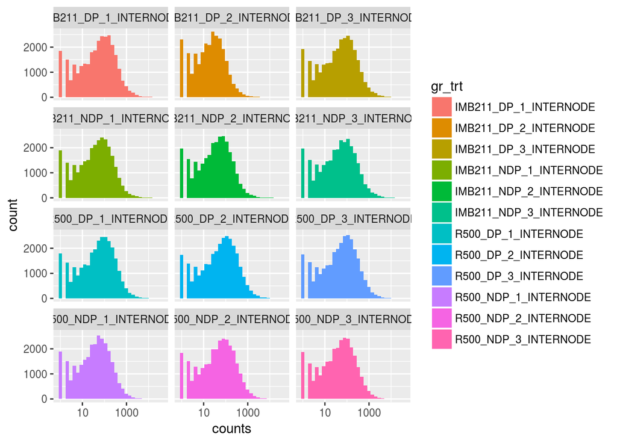

```r
ggplot(counts.data.melt,aes(x=counts,fill=gr_trt)) + geom_histogram() + scale_x_log10() +facet_wrap(facets= ~ gr_trt, ncol=3)
```

**b.** **Is the data normally distributed? Apply an appropriate transformation if needed and make a new set of histograms.**

Before transforming the data with scale_x_log10(), all the data seemed to lean left, with a strong right skew.

```r
counts.data <- counts.data[rowSums(counts.data > 10) >= 3,]
```

**Exercise 5:**  
**We expect that read counts, especially from biological replicates, will be highly correlated. Check to see if this is the case using the `pairs()` function and the `cor()` function. Explain what each of these functions does and comment on the results. **Important Hint:** *`pairs` is slow on the full dataset. Try it on the first 1,000 genes. Do you need to transform to make the pairs output more meaningful?***

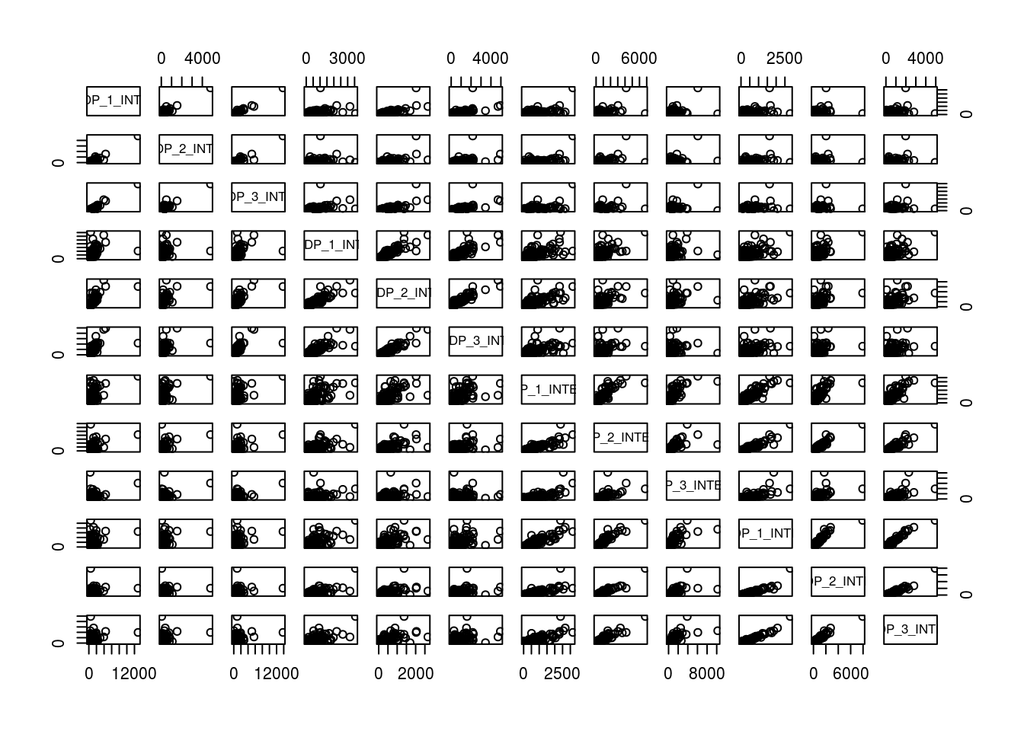

```r
pairs(counts.data[1:1000,])
```

```r
cor(counts.data)
```

```
##                        IMB211_DP_1_INTERNODE IMB211_DP_2_INTERNODE
## IMB211_DP_1_INTERNODE              1.0000000             0.8829467
## IMB211_DP_2_INTERNODE              0.8829467             1.0000000
## IMB211_DP_3_INTERNODE              0.9779624             0.8418256
## IMB211_NDP_1_INTERNODE             0.8458411             0.6236125
## IMB211_NDP_2_INTERNODE             0.9322233             0.7666273
## IMB211_NDP_3_INTERNODE             0.9091927             0.7600506
## R500_DP_1_INTERNODE                0.7383329             0.6794771
## R500_DP_2_INTERNODE                0.6682479             0.6613022
## R500_DP_3_INTERNODE                0.6549540             0.5940739
## R500_NDP_1_INTERNODE               0.6792354             0.6600087
## R500_NDP_2_INTERNODE               0.6612927             0.6407352
## R500_NDP_3_INTERNODE               0.6710454             0.6391966
##                        IMB211_DP_3_INTERNODE IMB211_NDP_1_INTERNODE
## IMB211_DP_1_INTERNODE              0.9779624              0.8458411
## IMB211_DP_2_INTERNODE              0.8418256              0.6236125
## IMB211_DP_3_INTERNODE              1.0000000              0.8690647
## IMB211_NDP_1_INTERNODE             0.8690647              1.0000000
## IMB211_NDP_2_INTERNODE             0.9119264              0.9390041
## IMB211_NDP_3_INTERNODE             0.9212701              0.9222051
## R500_DP_1_INTERNODE                0.6700529              0.7168699
## R500_DP_2_INTERNODE                0.6004433              0.6266002
## R500_DP_3_INTERNODE                0.5845980              0.6338798
## R500_NDP_1_INTERNODE               0.6166915              0.6701654
## R500_NDP_2_INTERNODE               0.6079059              0.6640211
## R500_NDP_3_INTERNODE               0.6132388              0.6677535
##                        IMB211_NDP_2_INTERNODE IMB211_NDP_3_INTERNODE
## IMB211_DP_1_INTERNODE               0.9322233              0.9091927
## IMB211_DP_2_INTERNODE               0.7666273              0.7600506
## IMB211_DP_3_INTERNODE               0.9119264              0.9212701
## IMB211_NDP_1_INTERNODE              0.9390041              0.9222051
## IMB211_NDP_2_INTERNODE              1.0000000              0.9582625
## IMB211_NDP_3_INTERNODE              0.9582625              1.0000000
## R500_DP_1_INTERNODE                 0.8095316              0.7021424
## R500_DP_2_INTERNODE                 0.7061980              0.6088471
## R500_DP_3_INTERNODE                 0.7174077              0.5905637
## R500_NDP_1_INTERNODE                0.7380183              0.6432128
## R500_NDP_2_INTERNODE                0.7125277              0.6272757
## R500_NDP_3_INTERNODE                0.7268725              0.6283412
##                        R500_DP_1_INTERNODE R500_DP_2_INTERNODE
```

[output cut: 23 more lines]

```
## R500_NDP_2_INTERNODE             0.8776934            0.9782606
## R500_NDP_3_INTERNODE             0.9084357            0.9884737
##                        R500_NDP_2_INTERNODE R500_NDP_3_INTERNODE
## IMB211_DP_1_INTERNODE             0.6612927            0.6710454
## IMB211_DP_2_INTERNODE             0.6407352            0.6391966
## IMB211_DP_3_INTERNODE             0.6079059            0.6132388
## IMB211_NDP_1_INTERNODE            0.6640211            0.6677535
## IMB211_NDP_2_INTERNODE            0.7125277            0.7268725
## IMB211_NDP_3_INTERNODE            0.6272757            0.6283412
## R500_DP_1_INTERNODE               0.8828422            0.8969530
## R500_DP_2_INTERNODE               0.9782868            0.9680142
## R500_DP_3_INTERNODE               0.8776934            0.9084357
## R500_NDP_1_INTERNODE              0.9782606            0.9884737
## R500_NDP_2_INTERNODE              1.0000000            0.9837720
## R500_NDP_3_INTERNODE              0.9837720            1.0000000
```

The pairs() command creates a plot while the cor() command lists numerical values. Because I used a smaller sample size to map with pairs, it seems fine without a transformation.

```r
sample.description <- data.frame(
  sample=colnames(counts.data),
  gt=regmatches(colnames(counts.data),regexpr("R500|IMB211",colnames(counts.data))),


  trt=regmatches(colnames(counts.data),regexpr("NDP|DP",colnames(counts.data)))
  )

sample.description$group <- paste(sample.description$gt,sample.description$trt,sep="_")

sample.description$trt <- relevel(sample.description$trt,ref="NDP")

head(sample.description)
```

```
##                   sample     gt trt      group
## 1  IMB211_DP_1_INTERNODE IMB211  DP  IMB211_DP
## 2  IMB211_DP_2_INTERNODE IMB211  DP  IMB211_DP
## 3  IMB211_DP_3_INTERNODE IMB211  DP  IMB211_DP
## 4 IMB211_NDP_1_INTERNODE IMB211 NDP IMB211_NDP
## 5 IMB211_NDP_2_INTERNODE IMB211 NDP IMB211_NDP
## 6 IMB211_NDP_3_INTERNODE IMB211 NDP IMB211_NDP
```

```r
summary(sample.description)
```

```
##                     sample       gt     trt       group
##  IMB211_DP_1_INTERNODE :1   IMB211:6   NDP:6   Length:12
##  IMB211_DP_2_INTERNODE :1   R500  :6   DP :6   Class :character
##  IMB211_DP_3_INTERNODE :1                      Mode  :character
##  IMB211_NDP_1_INTERNODE:1
##  IMB211_NDP_2_INTERNODE:1
##  IMB211_NDP_3_INTERNODE:1
##  (Other)               :6
```

```r
library(edgeR)
dge.data <- DGEList(counts=counts.data, group=sample.description$group)
dim(dge.data)
```

```
## [1] 24034    12
```

```r
dge.data <- calcNormFactors(dge.data, method = "TMM")
dge.data$samples
```

```
##                             group lib.size norm.factors
## IMB211_DP_1_INTERNODE   IMB211_DP  5490779    0.9599925
## IMB211_DP_2_INTERNODE   IMB211_DP  1510063    1.0071912
## IMB211_DP_3_INTERNODE   IMB211_DP  5201394    0.8859066
## IMB211_NDP_1_INTERNODE IMB211_NDP  3900431    0.9759586
## IMB211_NDP_2_INTERNODE IMB211_NDP  3079339    1.0014028
## IMB211_NDP_3_INTERNODE IMB211_NDP  4769616    0.9034489
## R500_DP_1_INTERNODE       R500_DP  4824927    1.0426105
## R500_DP_2_INTERNODE       R500_DP  5591866    1.0776337
## R500_DP_3_INTERNODE       R500_DP  5130017    1.0144761
## R500_NDP_1_INTERNODE     R500_NDP  3189641    1.0596401
## R500_NDP_2_INTERNODE     R500_NDP  4519535    1.0480216
## R500_NDP_3_INTERNODE     R500_NDP  3941106    1.0445393
```

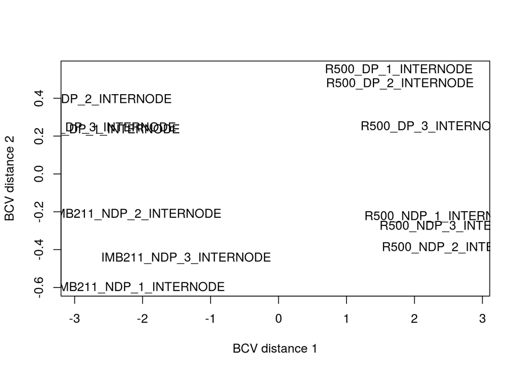

```r
plotMDS(dge.data, method = "bcv")
```

**Exercise 6**  
**Discuss the MDS plot. Does it give you confidence in the experiment or cause concern?**

Each group of internodes reside in a specific area on the plot: IMB211_DP in the top left, IMB211_NDP in the bottom left, R500_DP in the top right, and R500_NDP in the bottom right distances. Each group of internodes have similar biological coefficients of variance with each other. Similar internodes are plotted around the same distance (for example, all the R500_NDP internodes are clustered in the same area), so it seems to make sense, providing some confidence in the experiement.

**Exercise 7**  
To get a graphical idea for what the normalization does, make box plots of the count data for each sample before and after normalization. Discuss the effect of normalization.

```r
counts.data.normal <- cpm(dge.data)

library(reshape2)
counts.data.normal.melt<- melt(as.matrix(counts.data.normal),value.name="counts", varnames=c("geneID","gr_trt"))
head(counts.data.normal.melt)
```

```
##      geneID                gr_trt    counts
## 1 Bra000002 IMB211_DP_1_INTERNODE  3.794270
## 2 Bra000003 IMB211_DP_1_INTERNODE 43.254676
## 3 Bra000005 IMB211_DP_1_INTERNODE 62.226025
## 4 Bra000006 IMB211_DP_1_INTERNODE 21.247911
## 5 Bra000007 IMB211_DP_1_INTERNODE  2.276562
## 6 Bra000008 IMB211_DP_1_INTERNODE  3.794270
```

```r
summary(counts.data.normal.melt)
```

```
##        geneID                          gr_trt           counts
##  Bra000002:    12   IMB211_DP_1_INTERNODE : 24034   Min.   :   0.000
##  Bra000003:    12   IMB211_DP_2_INTERNODE : 24034   1st Qu.:   5.802
##  Bra000005:    12   IMB211_DP_3_INTERNODE : 24034   Median :  15.936
##  Bra000006:    12   IMB211_NDP_1_INTERNODE: 24034   Mean   :  41.682
##  Bra000007:    12   IMB211_NDP_2_INTERNODE: 24034   3rd Qu.:  40.107
##  Bra000008:    12   IMB211_NDP_3_INTERNODE: 24034   Max.   :8560.262
##  (Other)  :288336   (Other)               :144204
```

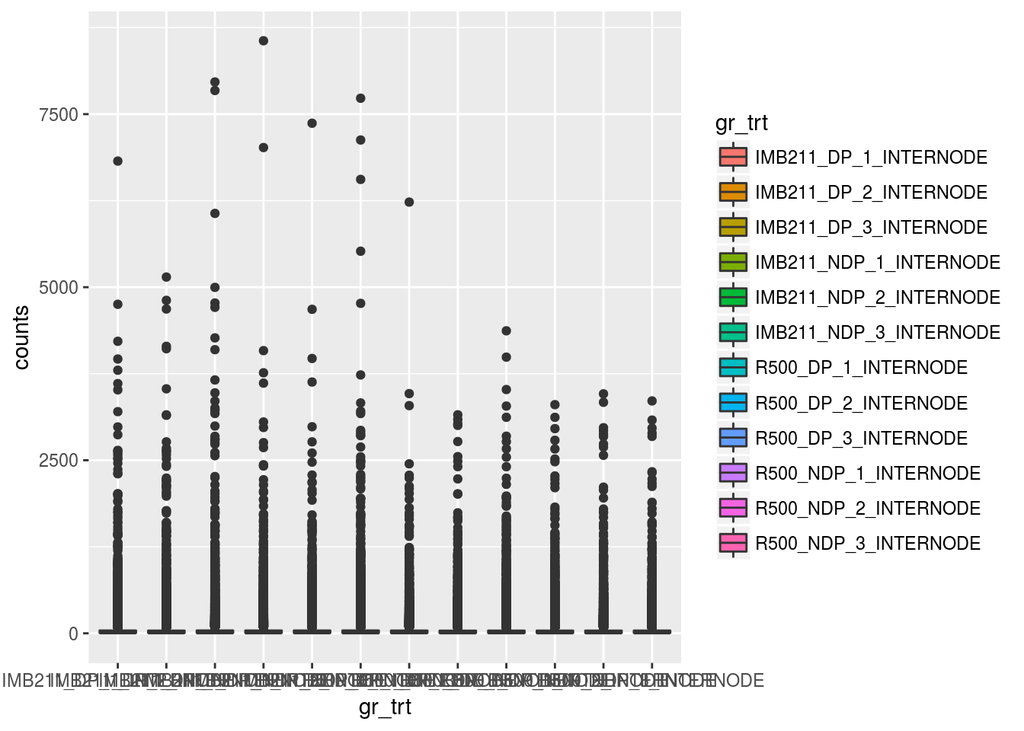

```r
ggplot(counts.data.normal.melt,aes(x=gr_trt, y=counts, fill=gr_trt)) + geom_boxplot()
```

```r
counts.data.log <- log2(counts.data + 1)
head(counts.data.log)
```

```
##           IMB211_DP_1_INTERNODE IMB211_DP_2_INTERNODE
## Bra000002              4.392317              4.700440
## Bra000003              7.839204              6.209453
## Bra000005              8.361944              6.539159
## Bra000006              6.820179              5.523562
## Bra000007              3.700440              2.807355
## Bra000008              4.392317              3.169925
##           IMB211_DP_3_INTERNODE IMB211_NDP_1_INTERNODE
## Bra000002              5.209453               5.321928
## Bra000003              7.531381               7.228819
## Bra000005              8.154818               8.233620
## Bra000006              6.149747               7.066089
## Bra000007              4.643856               3.000000
## Bra000008              4.087463               4.392317
##           IMB211_NDP_2_INTERNODE IMB211_NDP_3_INTERNODE
## Bra000002               5.930737               5.129283
## Bra000003               7.400879               7.400879
## Bra000005               7.693487               8.257388
## Bra000006               6.339850               6.781360
## Bra000007               3.000000               3.584963
## Bra000008               3.459432               4.523562
##           R500_DP_1_INTERNODE R500_DP_2_INTERNODE R500_DP_3_INTERNODE
## Bra000002            0.000000            3.459432            2.584963
## Bra000003            7.864186            7.794416            7.515700
## Bra000005            8.588715            9.357552            8.661778
## Bra000006            6.727920            7.209453            7.417853
## Bra000007            3.459432            1.584963            3.000000
## Bra000008            0.000000            1.584963            0.000000
##           R500_NDP_1_INTERNODE R500_NDP_2_INTERNODE R500_NDP_3_INTERNODE
## Bra000002             1.584963             2.000000             2.000000
## Bra000003             7.330917             7.276124             7.189825
## Bra000005             8.588715             8.962896             8.861087
## Bra000006             6.392317             7.108524             6.442943
## Bra000007             2.584963             2.000000             0.000000
## Bra000008             1.000000             2.000000             2.000000
```

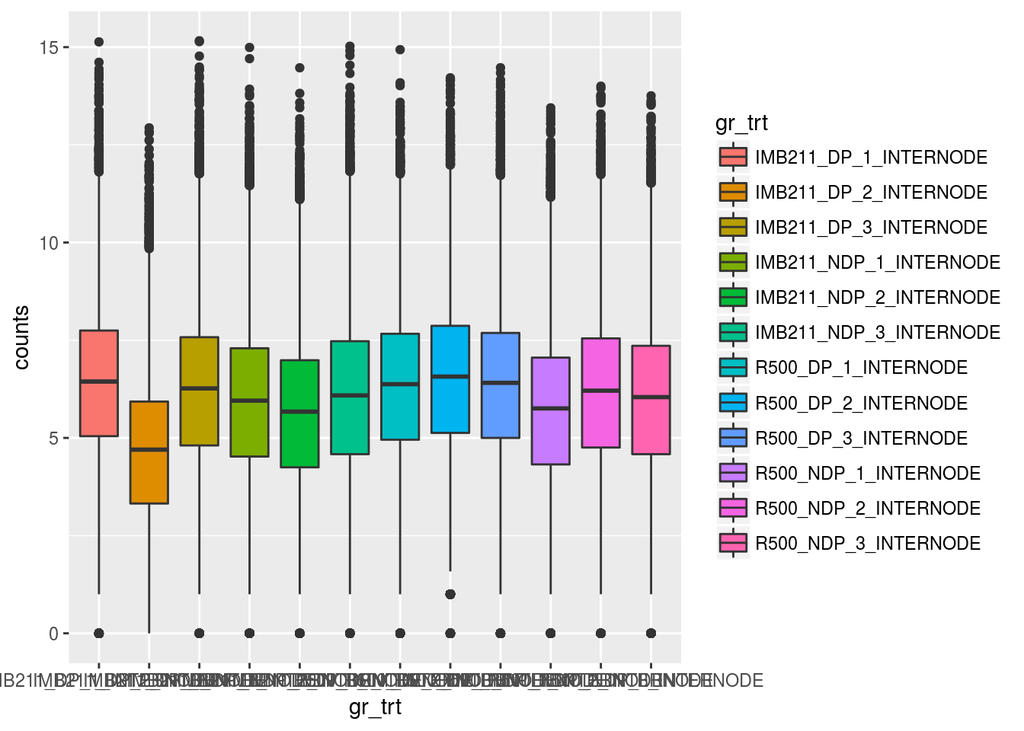

```r
counts.data.log.melt<- melt(as.matrix(counts.data.log),value.name="counts", varnames=c("geneID","gr_trt"))

ggplot(counts.data.log.melt,aes(x=gr_trt, y=counts, fill=gr_trt)) + geom_boxplot()
```

**Exercise 8**

```r
design <- model.matrix(~gt+trt,data = sample.description)
rownames(design) <- sample.description$sample
head(design)
```

```
##                        (Intercept) gtR500 trtDP
## IMB211_DP_1_INTERNODE            1      0     1
## IMB211_DP_2_INTERNODE            1      0     1
## IMB211_DP_3_INTERNODE            1      0     1
## IMB211_NDP_1_INTERNODE           1      0     0
## IMB211_NDP_2_INTERNODE           1      0     0
## IMB211_NDP_3_INTERNODE           1      0     0
```

```r
summary(design)
```

```
##   (Intercept)     gtR500        trtDP
##  Min.   :1    Min.   :0.0   Min.   :0.0
##  1st Qu.:1    1st Qu.:0.0   1st Qu.:0.0
##  Median :1    Median :0.5   Median :0.5
##  Mean   :1    Mean   :0.5   Mean   :0.5
##  3rd Qu.:1    3rd Qu.:1.0   3rd Qu.:1.0
##  Max.   :1    Max.   :1.0   Max.   :1.0
```

```r
dge.data <- estimateGLMCommonDisp(dge.data,design,verbose = TRUE)
```

```
## Disp = 0.058 , BCV = 0.2408
```

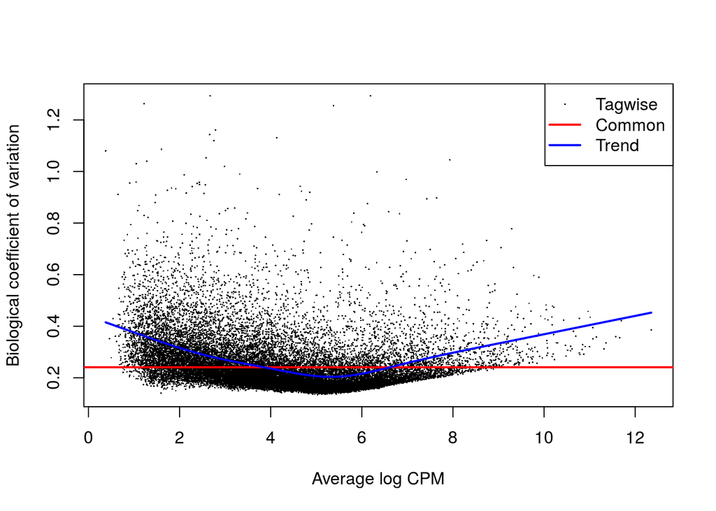

```r
dge.data <- estimateGLMTrendedDisp(dge.data,design)
dge.data <- estimateGLMTagwiseDisp(dge.data,design)

plotBCV(dge.data)
```

```r
fit <- glmFit(dge.data, design)
gt.lrt <- glmLRT(fit,coef = "gtR500")

topTags(gt.lrt)
```

```
## Coefficient:  gtR500
##                logFC   logCPM       LR        PValue           FDR
## Bra033098 -12.153105 6.070823 998.8288 3.227382e-219 7.756690e-215
## Bra023495 -11.889171 5.792298 974.5075 6.244234e-214 7.503696e-210
## Bra016271 -14.250692 8.144467 891.3678 7.385330e-196 5.916634e-192
## Bra020631 -11.318315 5.206858 870.7722 2.216713e-191 1.331912e-187
## Bra011216 -11.258770 5.133650 853.8519 1.057197e-187 5.081734e-184
## Bra020643 -14.383988 8.280736 841.0552 6.400269e-185 2.563734e-181
## Bra009785   7.950946 6.018503 786.8300 3.939943e-173 1.352751e-169
## Bra011765  -7.319947 6.341553 749.4443 5.299544e-165 1.592116e-161
## Bra026924  -8.334013 5.028260 729.9894 9.005258e-161 2.404804e-157
## Bra029392   8.339064 6.296476 723.1410 2.777521e-159 6.675494e-156
```

```r
summary(decideTestsDGE(gt.lrt,p.value=0.01))
```

```
##    [,1]
## -1  5487
## 0  13562
## 1   4985
```

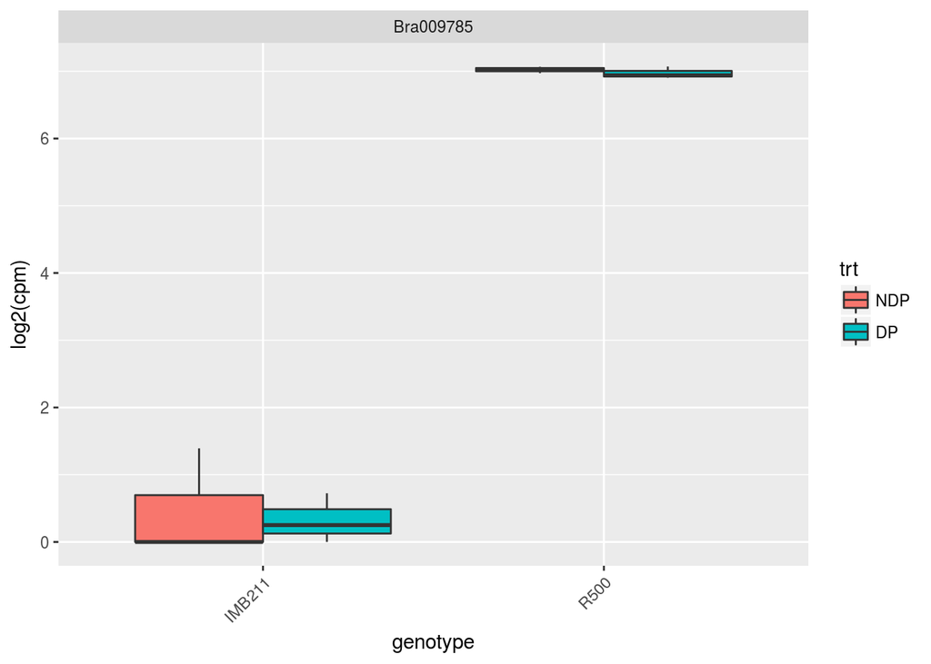

```r
DEgene.gt <- topTags(gt.lrt,n = Inf)$table[topTags(gt.lrt,n = Inf)$table$FDR<0.01,]
write.csv(DEgene.gt,"DEgenes.gt.csv")

plotDE <- function(genes, dge, sample.description) {
  require(ggplot2)
  require(reshape2)
  tmp.data <- t(log2(cpm(dge[genes,])+1))
  tmp.data <- merge(tmp.data,sample.description,by.x="row.names",by.y="sample")
  tmp.data <- melt(tmp.data,value.name="log2_cpm",variable.name="gene")
  pl <- ggplot(tmp.data,aes(x=gt,y=log2_cpm,fill=trt))
  pl <- pl + facet_wrap( ~ gene)
  pl <- pl + ylab("log2(cpm)") + xlab("genotype")
  pl <- pl + geom_boxplot()
  pl + theme(axis.text.x  = element_text(angle=45, vjust=1,hjust=1))
}

plotDE("Bra009785",dge.data,sample.description)
```

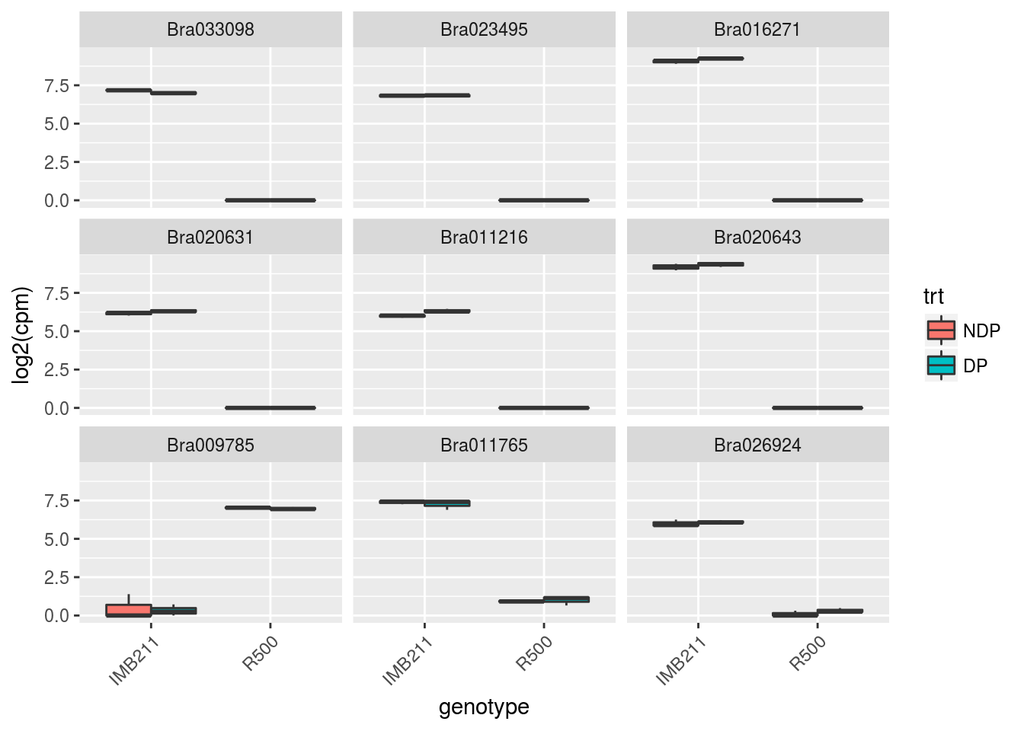

```r
plotDE(rownames(DEgene.gt)[1:9],dge.data,sample.description)
```

**a) Find all genes differentially expressed in response to the DP treatment (at a FDR < 0.01).**

```r
fit2 <- glmFit(dge.data, design)
trt.lrt <- glmLRT(fit2,coef = "trtDP")

topTags(trt.lrt)
```

```
## Coefficient:  trtDP
##               logFC   logCPM        LR       PValue          FDR
## Bra028803 -5.043456 3.514222 132.19854 1.353794e-30 3.253709e-26
## Bra019324  4.809736 2.209125  76.43637 2.274239e-18 2.732953e-14
## Bra034565  4.081287 2.159299  68.93415 1.018066e-16 8.156067e-13
## Bra025587  4.190919 3.298713  55.04401 1.178608e-13 7.081667e-10
## Bra029946  2.280844 5.364465  47.80173 4.715747e-12 1.898675e-08
## Bra026156  1.764672 6.467797  47.50653 5.482100e-12 1.898675e-08
## Bra030161  2.846792 5.105622  47.48949 5.529969e-12 1.898675e-08
## Bra037739  2.041482 4.539958  47.09441 6.764831e-12 2.032324e-08
## Bra016050  5.119232 1.755334  46.01184 1.175405e-11 3.138854e-08
## Bra029042  3.496552 1.240656  45.59897 1.451181e-11 3.487769e-08
```

```r
summary(decideTestsDGE(trt.lrt,p.value=0.01))
```

```
##    [,1]
## -1   199
## 0  23415
## 1    420
```

```r
DEgene.trt <- topTags(trt.lrt,n = Inf)$table[topTags(trt.lrt,n = Inf)$table$FDR<0.01,]
write.csv(DEgene.trt,"DEgenes.trt.csv")
head(DEgene.trt)
```

```
##               logFC   logCPM        LR       PValue          FDR
## Bra028803 -5.043456 3.514222 132.19854 1.353794e-30 3.253709e-26
## Bra019324  4.809736 2.209125  76.43637 2.274239e-18 2.732953e-14
## Bra034565  4.081287 2.159299  68.93415 1.018066e-16 8.156067e-13
## Bra025587  4.190919 3.298713  55.04401 1.178608e-13 7.081667e-10
## Bra029946  2.280844 5.364465  47.80173 4.715747e-12 1.898675e-08
## Bra026156  1.764672 6.467797  47.50653 5.482100e-12 1.898675e-08
```

```r
summary(DEgene.trt)
```

```
##      logFC             logCPM              LR             PValue
##  Min.   :-5.0435   Min.   : 0.4637   Min.   : 13.36   Min.   :0.000e+00
##  1st Qu.:-0.8933   1st Qu.: 2.8969   1st Qu.: 15.03   1st Qu.:3.199e-06
##  Median : 1.0558   Median : 4.2077   Median : 17.53   Median :2.826e-05
##  Mean   : 0.5801   Mean   : 4.2668   Mean   : 20.03   Mean   :6.151e-05
##  3rd Qu.: 1.5738   3rd Qu.: 5.3175   3rd Qu.: 21.69   3rd Qu.:1.058e-04
##  Max.   : 5.1192   Max.   :10.1789   Max.   :132.20   Max.   :2.566e-04
##       FDR
##  Min.   :0.0000000
##  1st Qu.:0.0004943
##  Median :0.0021910
##  Mean   :0.0031324
##  3rd Qu.:0.0054757
##  Max.   :0.0099644
```

**b)** **How many genes are differentially expressed?**

619 observations/genes

**c)** **Make a plot of the top 9**

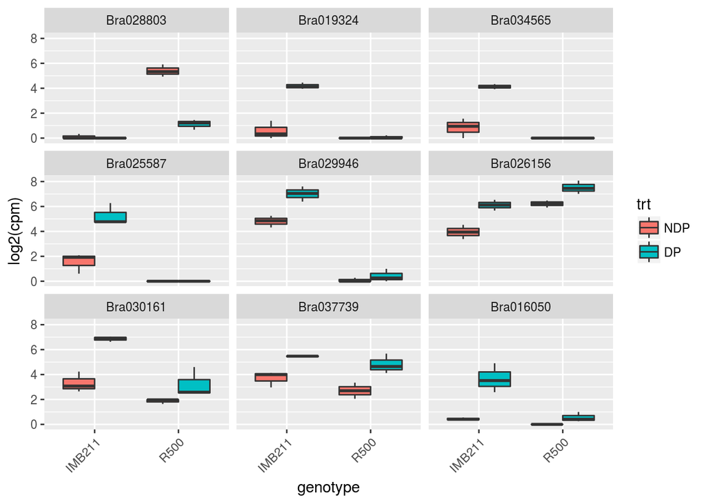

```r
plotDE(rownames(DEgene.trt)[1:9],dge.data,sample.description)
```

**Exercise 9**:

```r
design.interaction <- model.matrix(~gt*trt,data = sample.description)
rownames(design.interaction) <- sample.description$sample
summary(design.interaction)
```

```
##   (Intercept)     gtR500        trtDP      gtR500:trtDP
##  Min.   :1    Min.   :0.0   Min.   :0.0   Min.   :0.00
##  1st Qu.:1    1st Qu.:0.0   1st Qu.:0.0   1st Qu.:0.00
##  Median :1    Median :0.5   Median :0.5   Median :0.00
##  Mean   :1    Mean   :0.5   Mean   :0.5   Mean   :0.25
##  3rd Qu.:1    3rd Qu.:1.0   3rd Qu.:1.0   3rd Qu.:0.25
##  Max.   :1    Max.   :1.0   Max.   :1.0   Max.   :1.00
```

```r
head(design.interaction)
```

```
##                        (Intercept) gtR500 trtDP gtR500:trtDP
## IMB211_DP_1_INTERNODE            1      0     1            0
## IMB211_DP_2_INTERNODE            1      0     1            0
## IMB211_DP_3_INTERNODE            1      0     1            0
## IMB211_NDP_1_INTERNODE           1      0     0            0
## IMB211_NDP_2_INTERNODE           1      0     0            0
## IMB211_NDP_3_INTERNODE           1      0     0            0
```

**a)** **Repeat the dispersion estimates and model fit but with the new model. Show code.**

```r
dge.data2 <- estimateGLMCommonDisp(dge.data,design.interaction,verbose = TRUE)
```

```
## Disp = 0.0516 , BCV = 0.2272
```

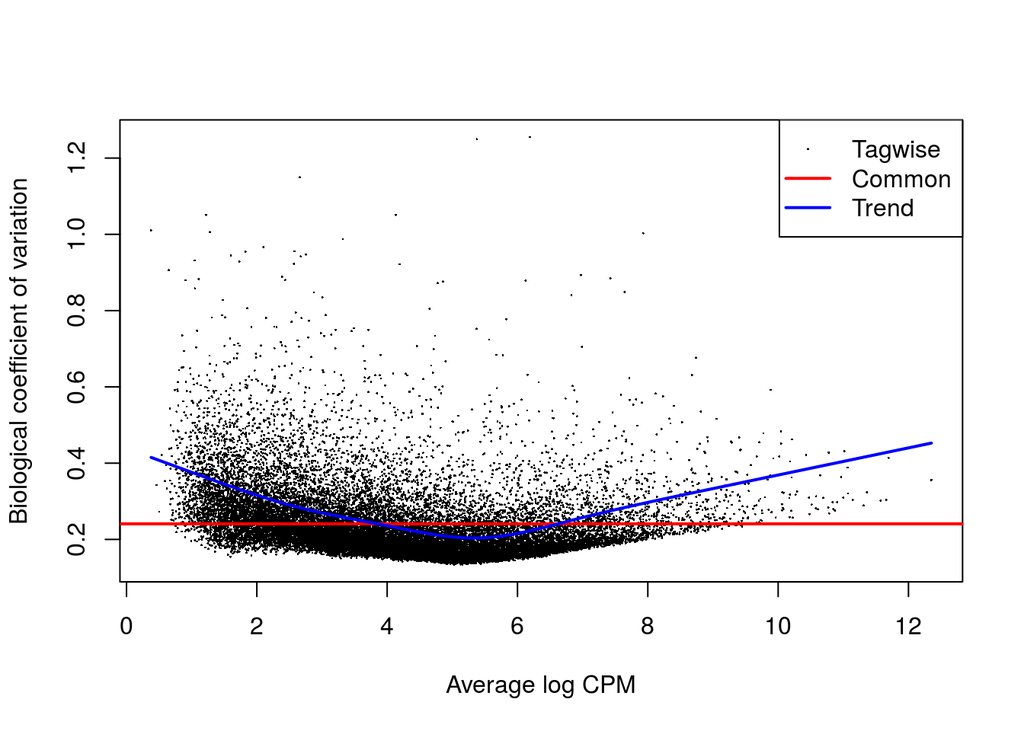

```r
dge.data2 <- estimateGLMTrendedDisp(dge.data,design.interaction)
dge.data2 <- estimateGLMTagwiseDisp(dge.data,design.interaction)

plotBCV(dge.data2)
```

```r
fit3 <- glmFit(dge.data2, design.interaction)
trt.lrt2 <- glmLRT(fit3,coef = "trtDP")

topTags(trt.lrt2)
```

```
## Coefficient:  trtDP
##               logFC   logCPM        LR       PValue          FDR
## Bra010821 -6.958526 6.039363 237.86674 1.147786e-53 2.758589e-49
## Bra035334  4.395904 4.672753 170.33734 6.244374e-39 7.503864e-35
## Bra041036  3.738663 7.165359 104.00830 2.014708e-24 1.614049e-20
## Bra017219  4.049603 7.611486  92.57514 6.481648e-22 3.894498e-18
## Bra019741 -4.039188 7.825972  90.18196 2.172336e-21 1.044199e-17
## Bra013164 -4.252912 9.328875  82.80506 9.055792e-20 3.627448e-16
## Bra018722  2.637365 3.955368  80.24416 3.308886e-19 1.136082e-15
## Bra003598  4.920818 3.899406  79.89769 3.943067e-19 1.184596e-15
## Bra019324  4.911450 2.209125  79.37995 5.124341e-19 1.368427e-15
## Bra011670  1.995012 5.180911  77.68853 1.206399e-18 2.899460e-15
```

```r
summary(decideTestsDGE(trt.lrt2,p.value=0.01))
```

```
##    [,1]
## -1   524
## 0  22820
## 1    690
```

**b)** **How many genes show a significantly different response to treatment in IMB211 as compared to R500? Save these genes to a file.**

```r
DEgene.trt.interaction <- topTags(trt.lrt2,n = Inf)$table[topTags(trt.lrt2,n = Inf)$table$FDR<0.01,]
write.csv(DEgene.trt.interaction,"DEgenes.trt.interaction.csv")
head(DEgene.trt.interaction)
```

```
##               logFC   logCPM        LR       PValue          FDR
## Bra010821 -6.958526 6.039363 237.86674 1.147786e-53 2.758589e-49
## Bra035334  4.395904 4.672753 170.33734 6.244374e-39 7.503864e-35
## Bra041036  3.738663 7.165359 104.00830 2.014708e-24 1.614049e-20
## Bra017219  4.049603 7.611486  92.57514 6.481648e-22 3.894498e-18
## Bra019741 -4.039188 7.825972  90.18196 2.172336e-21 1.044199e-17
## Bra013164 -4.252912 9.328875  82.80506 9.055792e-20 3.627448e-16
```

```r
summary(DEgene.trt.interaction)
```

```
##      logFC            logCPM              LR             PValue
##  Min.   :-7.964   Min.   : 0.6182   Min.   : 12.10   Min.   :0.000e+00
##  1st Qu.:-1.541   1st Qu.: 3.1057   1st Qu.: 14.59   1st Qu.:2.934e-07
##  Median : 1.082   Median : 4.3491   Median : 18.40   Median :1.789e-05
##  Mean   : 0.183   Mean   : 4.4741   Mean   : 22.90   Mean   :8.870e-05
##  3rd Qu.: 1.833   3rd Qu.: 5.7020   3rd Qu.: 26.29   3rd Qu.:1.337e-04
##  Max.   : 6.764   Max.   :10.1789   Max.   :237.87   Max.   :5.047e-04
##       FDR
##  Min.   :0.000e+00
##  1st Qu.:2.316e-05
##  Median :7.073e-04
##  Mean   :2.118e-03
##  3rd Qu.:3.527e-03
##  Max.   :9.992e-03
```

1214 observations/genes

**c)** **Make a plot of the top 9 genes that have a significantly different response to treatment in IMB211 as compared to R500.**

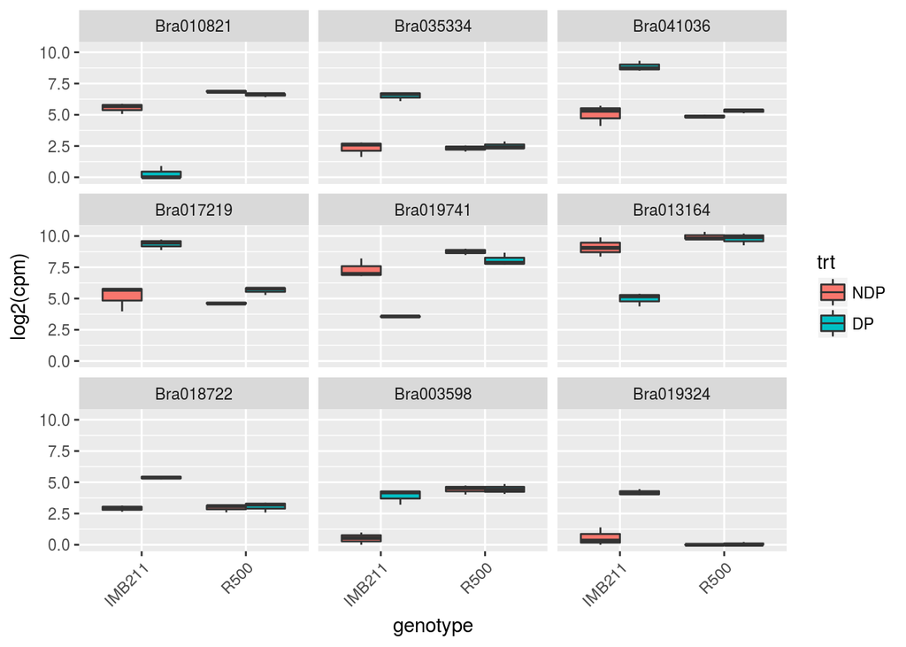

```r
plotDE(rownames(DEgene.trt.interaction)[1:9],dge.data2,sample.description)
```